# Morphological profiling workflows: Transformation and Normalization

Cytomining Hackathon attendees: Joseph Barry, Florian Heigwer, Mathias Wawer

2016-06-10

## Load data

First, load the data, which is stored in a database backend

```r
fixture <- '~/tmp/BBBC021.sqlite'

if (!file.exists(fixture)) {
  download.file("http://www.broadinstitute.org/~shsingh/BBBC021.sqlite",
              destfile = fixture,
              method = "curl",
              quiet = FALSE, mode = "w",
              cacheOK = TRUE,
              extra = getOption("download.file.extra"))
}

db <- src_sqlite(path = fixture)

images <-
  tbl(src = db, "supplement_Image")

objects <-
  tbl(src = db, "supplement_Object")

metadata <-
  tbl(src = db, "supplement_GroundTruth") %>%
  rename(Image_Metadata_Compound = compound,
         Image_Metadata_Concentration = concentration,
         Image_Metadata_MOA = moa)

images %<>%
  inner_join(
    metadata,
    by = c("Image_Metadata_Compound", "Image_Metadata_Concentration")
  )

data <-
  inner_join(images,
             objects,
             by = c("TableNumber", "ImageNumber")
  ) %>%
  compute()
```

Subset data for easier computation

```r
df <- collect(data)
unique(df$Image_Metadata_Plate_DAPI) # check for the unique plate metadata
```

```
##  [1] "Week1_22123"  "Week1_22141"  "Week1_22161"  "Week2_24121"
##  [5] "Week2_24141"  "Week2_24161"  "Week1_22361"  "Week1_22381"
##  [9] "Week1_22401"  "Week4_27801"  "Week4_27821"  "Week4_27861"
## [13] "Week3_25421"  "Week3_25441"  "Week3_25461"  "Week9_39206"
## [17] "Week9_39221"  "Week9_39222"  "Week9_39282"  "Week9_39283"
## [21] "Week9_39301"  "Week3_25681"  "Week3_25701"  "Week3_25721"
## [25] "Week8_38203"  "Week8_38221"  "Week8_38241"  "Week8_38341"
## [29] "Week8_38342"  "Week5_28901"  "Week5_28921"  "Week5_28961"
## [33] "Week10_40111" "Week10_40115" "Week10_40119" "Week7_34661"
## [37] "Week7_34681"  "Week7_34341"  "Week7_34381"  "Week7_34641"
## [41] "Week6_31641"  "Week6_31661"  "Week6_31681"  "Week2_24361"
## [45] "Week2_24381"  "Week2_24401"  "Week4_27481"  "Week4_27521"
## [49] "Week4_27542"  "Week5_29301"  "Week5_29321"  "Week5_29341"
## [53] "Week6_32061"  "Week6_32121"  "Week6_32161"
```

```r
dfs <- filter(df, grepl("Week[1|2]_", Image_Metadata_Plate_DAPI)) # only keep those plaze containning data fom week 1 and 2
dim(dfs) #get a glimpse of the size of the acquired data set
```

```
## [1] 92761   517
```

In the next step we choose our favourite features for illustration and compare their distributions before and after transformation.

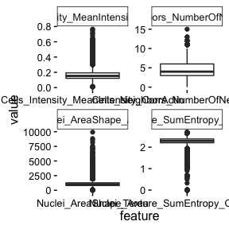

```r
feat <- grep("Nuclei_|Cells_|Cytoplasm_", colnames(dfs), value=TRUE)
nFeat <- length(feat)
favFeat <- c("Nuclei_AreaShape_Area",
             "Cells_Neighbors_NumberOfNeighbors_10",
             "Cells_Intensity_MeanIntensity_CorrActin",
             "Nuclei_Texture_SumEntropy_CorrDAPI_10")

dfl <- gather(dfs[, favFeat], feature, value)
ggplot(dfl, aes(x=feature, y=value))+facet_wrap(~feature, scale="free") +
  geom_boxplot() +
  theme_classic()
```

```r
dflLog <- mutate(dfl, value=log(value))
```

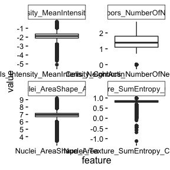

```r
ggplot(dflLog, aes(x=feature, y=value))+facet_wrap(~feature, scale="free") +
  geom_boxplot() +
  theme_classic()
```

```r
#due to negative and zero values in the data frame a lot of NAs are produced by the logarithm
sum(is.na(dflLog$value) | is.infinite(dflLog$value)) #count the non-finite values produced by regular logarithm
```

```
## [1] 3376
```

For many skewed feature density distributions log looks like a good transformation (e.g. Nuclei_AreaShape_Area). However over 3,000 cells have been removed. To solve this problem we instead try a generalized log tranform.

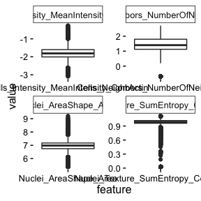

```r
glog <- function(x, c) log( (x + (x ^ 2 + c ^ 2) ^ 0.5 ) / 2) #define the glog-transform

#define some helper function to transform each feature individually
glogTransform <- function(x, q=0.05) {
    xq <- quantile(x, q, na.rm=TRUE)
    glog(x, xq)
}
dfsGlog <- dfs %>% mutate_each_(funs(glogTransform), feat)
dflGlog <- gather(dfsGlog[, favFeat], feature, value)
ggplot(dflGlog, aes(x=feature, y=value))+facet_wrap(~feature, scale="free")+
  geom_boxplot() +
  theme_classic()
```

```r
sum(is.na(dflLog$value) | is.infinite(dflLog$value)) #count the non-finite values produced by regular logarithm
```

```
## [1] 3376
```

Plate and batch effects can be assessed d by plotting representative measures, which ,in principle, should be independent of the plate and batch against those covariates. In a perfect dataset one would expect there means to be placed on a straight average line through the plate or batch for any covariate.

```r
colnames(dfsGlog[,! colnames(dfsGlog) %in% feat])
```

```
##  [1] "TableNumber"
##  [2] "ImageNumber"
##  [3] "Image_FileName_DAPI"
##  [4] "Image_PathName_DAPI"
##  [5] "Image_FileName_Tubulin"
##  [6] "Image_PathName_Tubulin"
##  [7] "Image_FileName_CellMask"
##  [8] "Image_PathName_CellMask"
##  [9] "Image_FileName_Actin"
## [10] "Image_PathName_Actin"
## [11] "Image_Metadata_Plate_DAPI"
## [12] "Image_Metadata_Well_DAPI"
## [13] "Image_FileName_DAPIillum"
## [14] "Image_PathName_DAPIillum"
## [15] "Image_FileName_ActinIllum"
```

[output cut: 26 more lines]

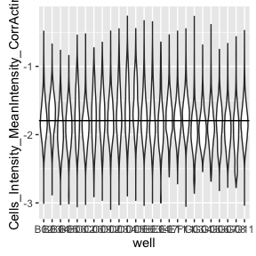

```r
dfsGlog$well=dfsGlog$Image_Metadata_Well_DAPI
dfsGlog$plate=dfsGlog$Image_Metadata_Plate_DAPI

ggplot(dfsGlog,aes(y=Cells_Intensity_MeanIntensity_CorrActin,x=well)) + geom_violin() + geom_hline(yintercept = mean(dfsGlog$Cells_Intensity_MeanIntensity_CorrActin))
```

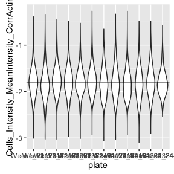

```r
ggplot(dfsGlog,aes(y=Cells_Intensity_MeanIntensity_CorrActin,x=plate)) + geom_violin() + geom_hline(yintercept = mean(dfsGlog$Cells_Intensity_MeanIntensity_CorrActin))
```

Here, Intensity looks like it does not need any normalization as the estamated means do not systematically or drastically deviate from the mean. Are other features the same? To clarify this question we choose to calculate the standard deviation of the plate medians per feature.

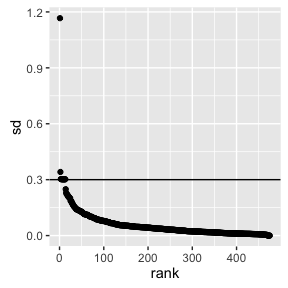

```r
plateMedianAcrossFeatures <- dfsGlog %>% group_by(plate) %>% summarize_each_(funs(median), feat)

ftSdAcrossPlateMedians <- plateMedianAcrossFeatures %>% summarize_each_(funs(sd), feat)
ftSdAcrossPlateMedians <- unlist(ftSdAcrossPlateMedians)
ftSdAcrossPlateMedians <- ftSdAcrossPlateMedians[order(ftSdAcrossPlateMedians, decreasing=TRUE)]
dfFt <- data.frame(rank=seq_along(ftSdAcrossPlateMedians), sd=ftSdAcrossPlateMedians,lab=as.character(names(ftSdAcrossPlateMedians)))
ggplot(dfFt, aes(x=rank, y=sd))+geom_point()+geom_hline(yintercept=0.3)
```

```r
dfExclude <- filter(dfFt, sd >= 0.3)
print(dfExclude)
```

```
##    rank        sd                                           lab
## 1     1 1.1664553           Nuclei_Neighbors_PercentTouching_10
## 2     2 0.3412821         Nuclei_Neighbors_NumberOfNeighbors_20
## 3     3 0.3031342  Nuclei_Neighbors_FirstClosestObjectNumber_10
## 4     4 0.3031342  Nuclei_Neighbors_FirstClosestObjectNumber_20
## 5     5 0.3025601   Cells_Neighbors_SecondClosestObjectNumber_3
## 6     6 0.3025601  Cells_Neighbors_SecondClosestObjectNumber_10
## 7     7 0.3023092    Cells_Neighbors_FirstClosestObjectNumber_3
## 8     8 0.3023092   Cells_Neighbors_FirstClosestObjectNumber_10
## 9     9 0.3022330                           Cells_Parent_Nuclei
## 10   10 0.3022330                        Cytoplasm_Parent_Cells
## 11   11 0.3022330                       Cytoplasm_Parent_Nuclei
## 12   12 0.3022068 Nuclei_Neighbors_SecondClosestObjectNumber_10
## 13   13 0.3022068 Nuclei_Neighbors_SecondClosestObjectNumber_20
```

We choose to exclude features that have a high variability across screening batches, since we do not expect an entire plate to be significantly different than the others.

Most features have low variability according to the above measure. We do not see the need to perform additional batch normalization. However for illustration purposes we perform a simple median normalization on each plate. removing per plate biases of measurements.

```r
dim(dfsGlog)
```

```
## [1] 92761   519
```

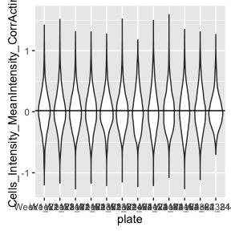

```r
norm.fun<-function(x){
  return(x-median(x))
}

dfsGlog %<>% group_by(plate) %>% mutate_each_(funs(norm.fun), feat) %>% ungroup()

dfsGlog <- select(dfsGlog, -one_of(as.character(dfExclude$lab)))

ggplot(dfsGlog,aes(y=Cells_Intensity_MeanIntensity_CorrActin,x=plate)) + geom_violin() + geom_hline(yintercept = mean(dfsGlog$Cells_Intensity_MeanIntensity_CorrActin))
```

```r
dim(dfsGlog)
```

```
## [1] 92761   506
```

From there we can assume the dataset to be unbiased so we can perform all further scaling steps on the basis of the entire dataset regardless of well or plate location. There are two ways of performing scaling. The first estimates the median(mean) and mad (sd) on the population of negative controls (here: DMSO). And the second uses the entire dataset. When z-scaling using the negative controls one can infer from the z-score if a perturbation is more or less distant from the negative controls (so its general activity). On the other hand, when using the entire dataset for scaling we can infer information on the significance of the perturbation effect compared to all other perturbations. If the assumption holds true that most compounds of the library are inactive both approaches lead to the same result.

Where are the negative controls?

```r
colnames(dfsGlog)[! colnames(dfsGlog) %in% feat]
```

```
##  [1] "TableNumber"
##  [2] "ImageNumber"
##  [3] "Image_FileName_DAPI"
##  [4] "Image_PathName_DAPI"
##  [5] "Image_FileName_Tubulin"
##  [6] "Image_PathName_Tubulin"
##  [7] "Image_FileName_CellMask"
##  [8] "Image_PathName_CellMask"
##  [9] "Image_FileName_Actin"
## [10] "Image_PathName_Actin"
## [11] "Image_Metadata_Plate_DAPI"
## [12] "Image_Metadata_Well_DAPI"
## [13] "Image_FileName_DAPIillum"
## [14] "Image_PathName_DAPIillum"
## [15] "Image_FileName_ActinIllum"
```

[output cut: 28 more lines]

```r
unique(dfsGlog$Image_Metadata_Compound)
```

```
##  [1] "cytochalasin B" "cytochalasin D" "latrunculin B"  "AZ-A"
##  [5] "methotrexate"   "colchicine"     "nocodazole"     "epothilone B"
##  [9] "taxol"          "ALLN"           "MG-132"         "DMSO"
```

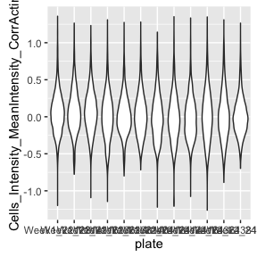

```r
dfDMSO <- filter(dfsGlog, Image_Metadata_Compound == "DMSO")
ggplot(dfDMSO,aes(y=Cells_Intensity_MeanIntensity_CorrActin,x=plate)) + geom_violin()
```

```r
unique(dfDMSO$well)
```

```
## [1] "B02" "C02" "D02" "E11" "F11" "G11"
```

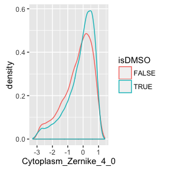

```r
dfsGlog$isDMSO <- dfsGlog$Image_Metadata_Compound == "DMSO"
ggplot(dfsGlog, aes(x=Cytoplasm_Zernike_4_0, col=isDMSO))+geom_density()
```

```r
feat <- feat[! feat %in% dfExclude$lab]
controlMedian <- dfsGlog %>% group_by(isDMSO) %>% summarize_each_(funs(median), feat)
controlDiff <- controlMedian %>% summarize_each_(funs(diff), feat)
controlDiff <- unlist(controlDiff)
controlDiff <- controlDiff[order(controlDiff, decreasing=TRUE)]
head(controlDiff, 20)
```

```
##                  Cells_Neighbors_NumberOfNeighbors_3
##                                            0.2762661
##                 Cells_Neighbors_NumberOfNeighbors_10
##                                            0.2762661
##                                Cytoplasm_Zernike_6_0
##                                            0.2365367
##                                Cytoplasm_Zernike_4_0
##                                            0.2204075
##                                   Nuclei_Zernike_4_0
##                                            0.2056182
##                    Cells_Neighbors_PercentTouching_3
##                                            0.1906691
##                                   Nuclei_Zernike_6_0
##                                            0.1723989
##            Nuclei_Neighbors_AngleBetweenNeighbors_10
##                                            0.1719106
##            Nuclei_Neighbors_AngleBetweenNeighbors_20
##                                            0.1719106
##              Cells_Neighbors_AngleBetweenNeighbors_3
##                                            0.1678657
##             Cells_Neighbors_AngleBetweenNeighbors_10
##                                            0.1678657
##    Cytoplasm_Intensity_IntegratedIntensity_CorrActin
##                                            0.1439142
##                   Cells_Neighbors_PercentTouching_10
##                                            0.1339091
##          Nuclei_Intensity_MinIntensityEdge_CorrActin
##                                            0.1304729
##                                   Nuclei_Zernike_7_7
##                                            0.1281827
##                             Cytoplasm_AreaShape_Area
##                                            0.1222599
##                                   Nuclei_Zernike_8_0
##                                            0.1200984
##              Nuclei_Intensity_MinIntensity_CorrActin
##                                            0.1183106
##                                   Nuclei_Zernike_5_5
##                                            0.1139234
## Cytoplasm_Intensity_LowerQuartileIntensity_CorrActin
##                                            0.1124328
```

DMSO appears to be mimicking the behaviour of the other wells.

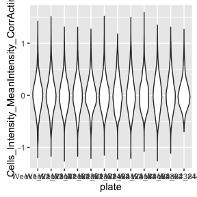

```r
zDMSO <- function(x, isDMSO) (x-median(x[isDMSO], na.rm=TRUE))/(mad(x[isDMSO], na.rm=TRUE)*1.48)

dfDMSO <- dfsGlog %>% group_by(plate) %>% mutate_each_(funs(zDMSO(., isDMSO)), feat) %>% ungroup()
ggplot(dfsGlog,aes(y=Cells_Intensity_MeanIntensity_CorrActin,x=plate)) + geom_violin()
```

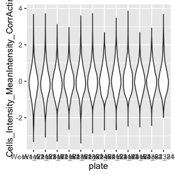

```r
ggplot(dfDMSO,aes(y=Cells_Intensity_MeanIntensity_CorrActin,x=plate)) + geom_violin()
```

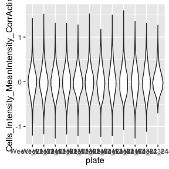

```r
#alternatively one can estimate the median to scale to from each plate and the sd or mad from the entire dataset in order to gain statistical power on the mad estimation
zDMSO.alt <- function(x, isDMSO,m){
  (x-median(x[isDMSO], na.rm=TRUE))/m*1.48
}

mads=summarise_each_(dfsGlog,funs(mad(.,na.rm = T)),feat)
dfDMSO.mad=dfsGlog
for(f in feat){
  dfDMSO.mad %<>% group_by(plate) %>% mutate_each_(funs(zDMSO.alt(., isDMSO,mads[[f]])), f) %>% ungroup()
}

ggplot(dfsGlog,aes(y=Cells_Intensity_MeanIntensity_CorrActin,x=plate)) + geom_violin()
```

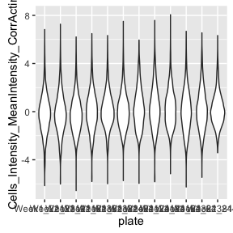

```r
ggplot(dfDMSO.mad,aes(y=Cells_Intensity_MeanIntensity_CorrActin,x=plate)) + geom_violin()
```